# Predicting Yearly Salary for NBA Players: 1990-2017

#### Offensive Rebounds

Figure 32 shows the untransformed distribution for offensive rebounds, while Figure 33 shows the distribution after the variable’s transformed.

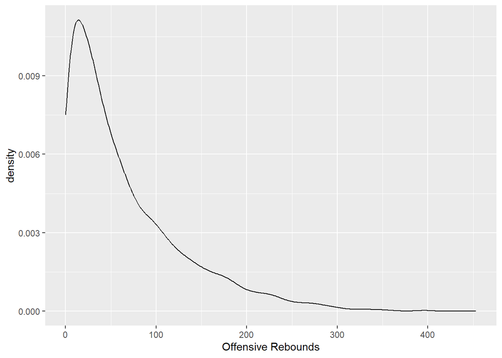

Figure 32: Offensive Rebounds Distribution

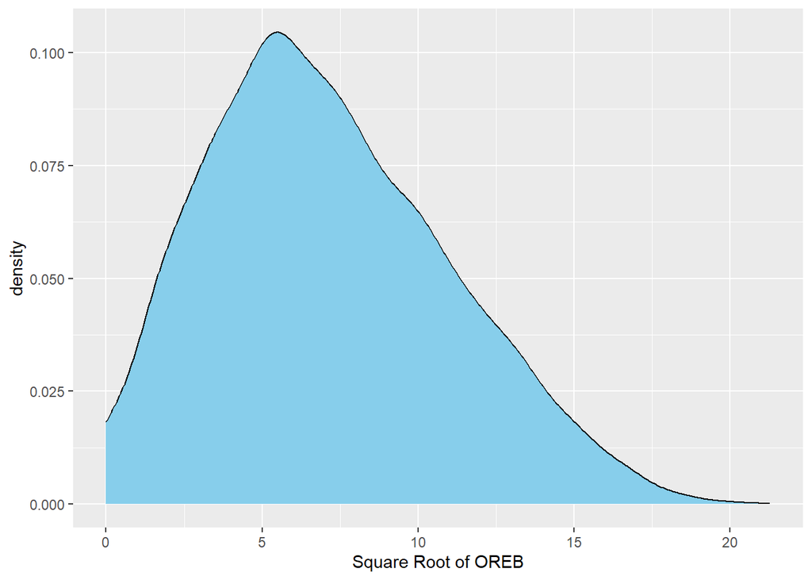

Figure 33: Offensive Rebunds Distribution (Square-Root Transformed)

Now, let’s look at log-based transformations. For these variables, I noticed that certain values were missing – that was because these variables all had values that were 0 or lower that forced missing values to arise. As a result, to apply something equivalent to the log transformation effect in the recipe, I applied a Yeo-Johnson transformation in the recipe to the following variables.

Here, I’ll compare their untransformed distributions versus their log-transformed ones.

#### Offensive Win Shares

Figure 34 shows the untransformed distribution for offensive win shares, while Figure 35 shows the distribution after the variable’s transformed.

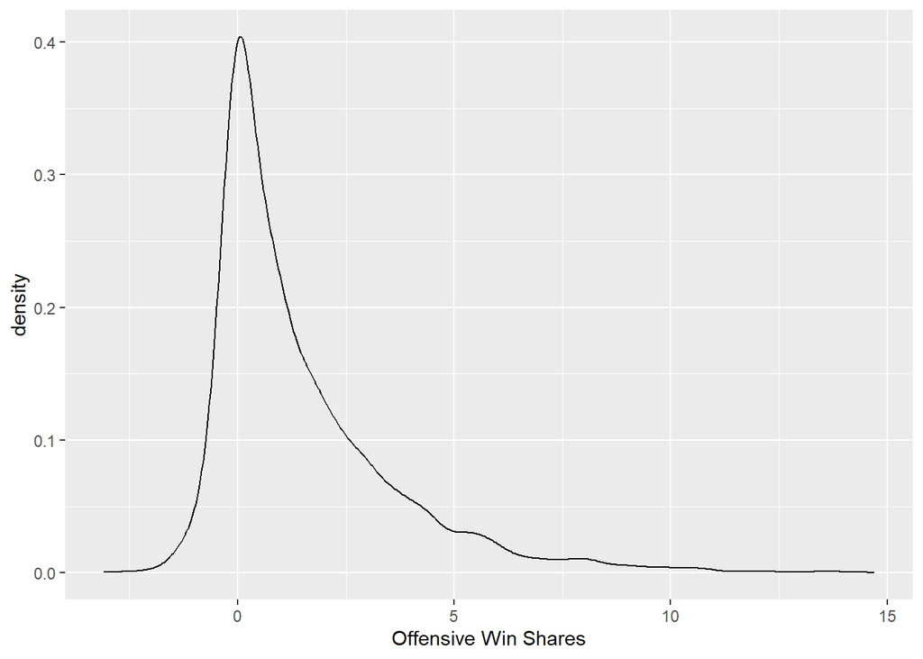

Figure 34: Offensive Win Shares Distribution

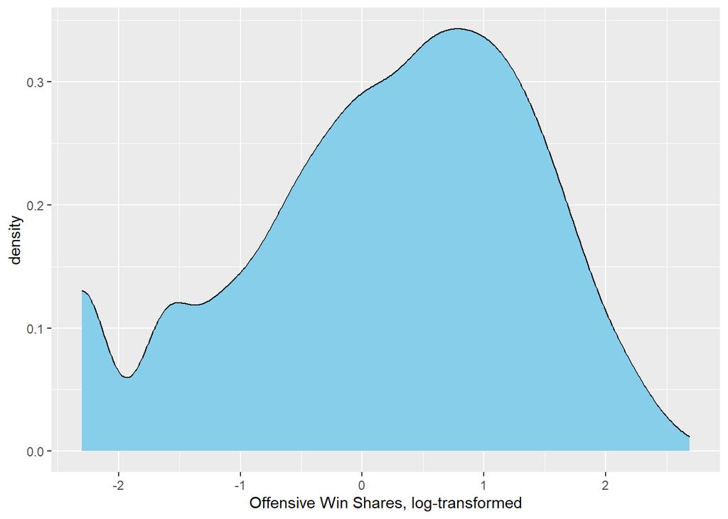

Figure 35: Offensive Win Shares Distribution (Log-Transformed)

#### Defensive Win Shares

Figure 36 shows the untransformed distribution for defensive win shares, while Figure 37 shows the distribution after the variable’s transformed.

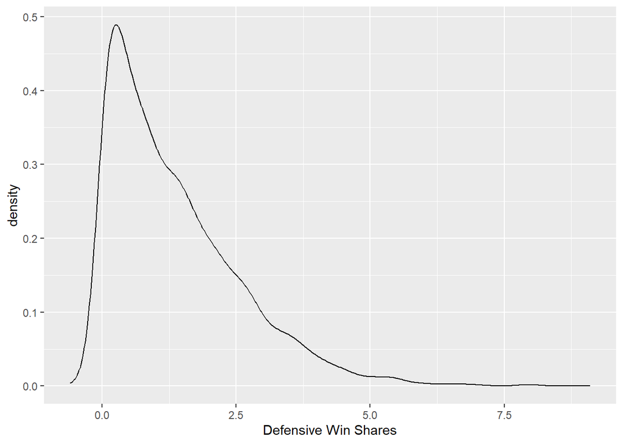

Figure 36: Defensive Win Shares Distribution

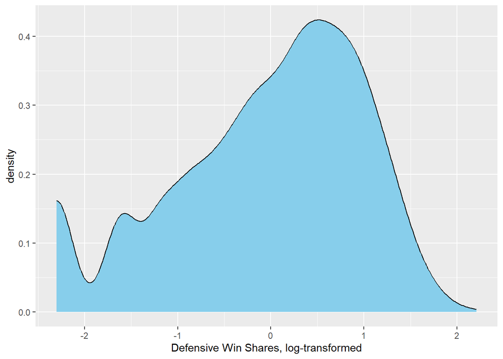

Figure 37: Defensive Win Shares Distribution (Log-Transformed)

#### Win Shares

Figure 38 shows the untransformed distribution for win shares, while Figure 39 shows the distribution after the variable’s transformed.

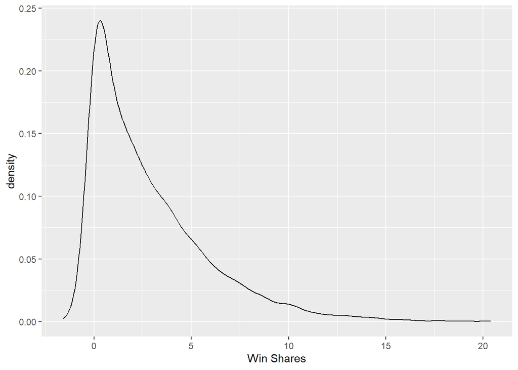

Figure 38: Win Shares Distribution

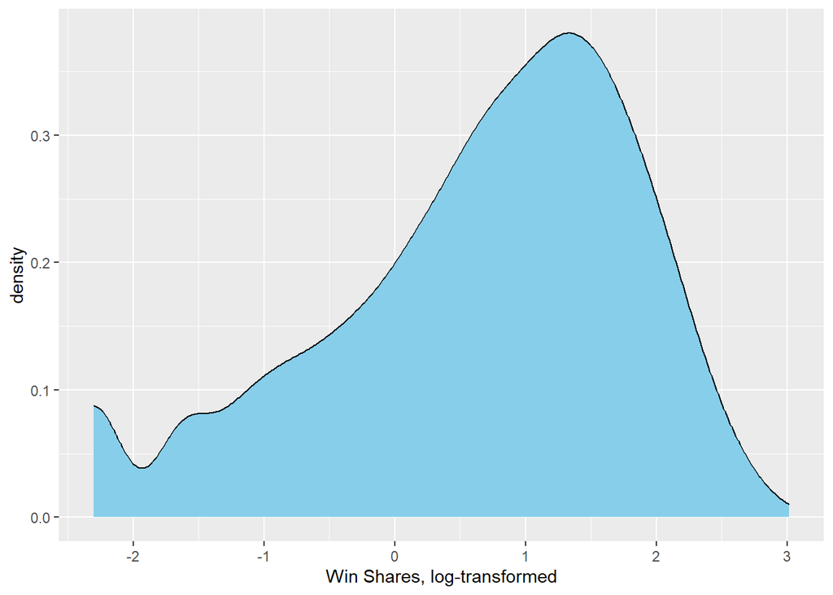

Figure 39: Win Shares Distribution (Log-Transformed)

#### Value Over Replacement (VORP)

Figure 40 shows the untransformed distribution for VORP, while Figure 41 shows the distribution after the variable’s transformed.

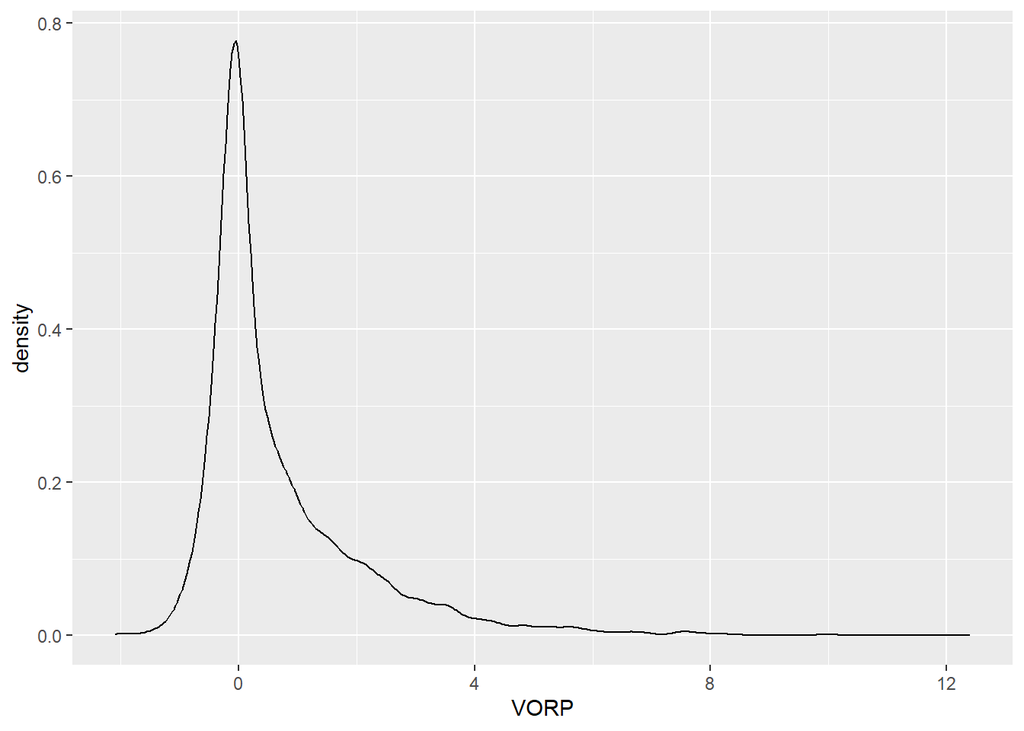

Figure 40: VORP Distribution

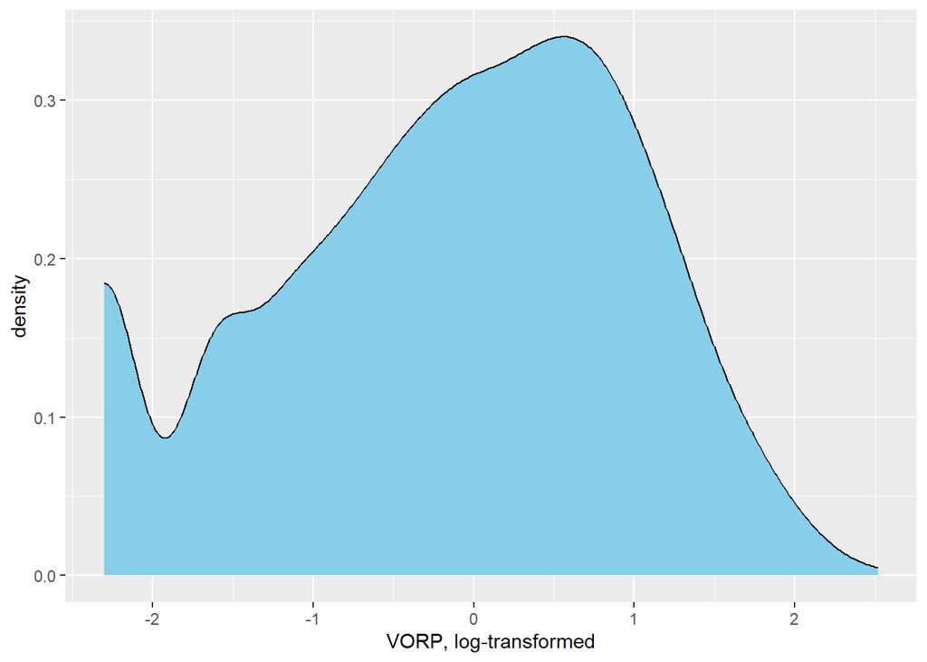

Figure 41: VORP Distribution (Log-Transformed)

#### Player Efficiency Rating (PER)

Figure 42 shows the untransformed distribution for PER, while Figure 43 shows the distribution after the variable’s transformed. I added a square-root transformation for this, though there are negative values, which is why I applied the YeoJohnson transformation in the recipe.

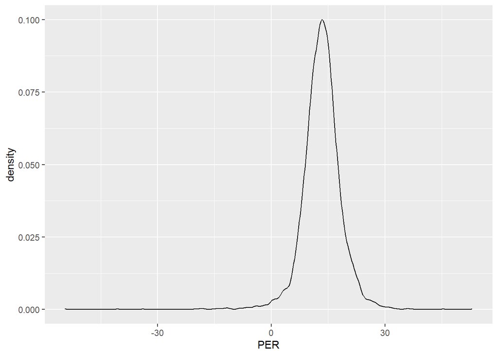

Figure 42: PER Distribution

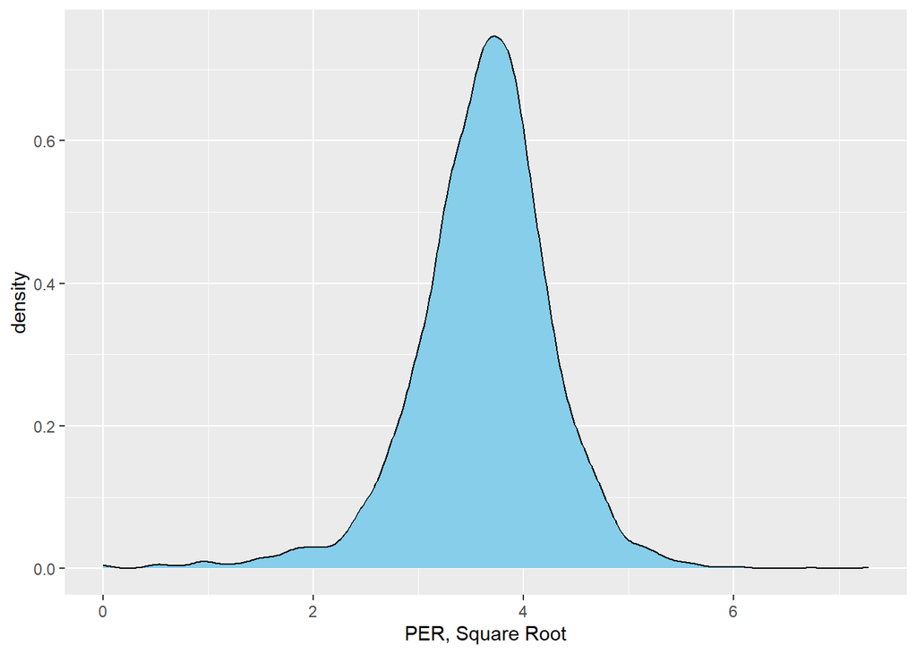

Figure 43: PER Distribution (Square Root)

#### Three-pointers made and attempted

Figure 44 shows the untransformed distribution for three-pointers made, while Figure 44 shows the distribution after the variable’s transformed. Attempts follow a very similar distribution.

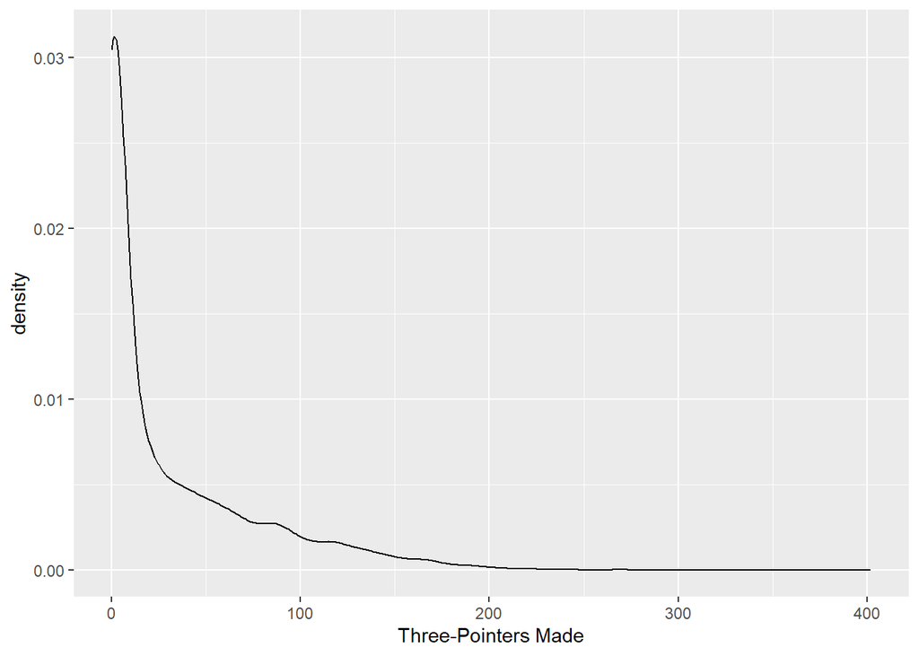

Figure 44: Three-Pointers Distribution

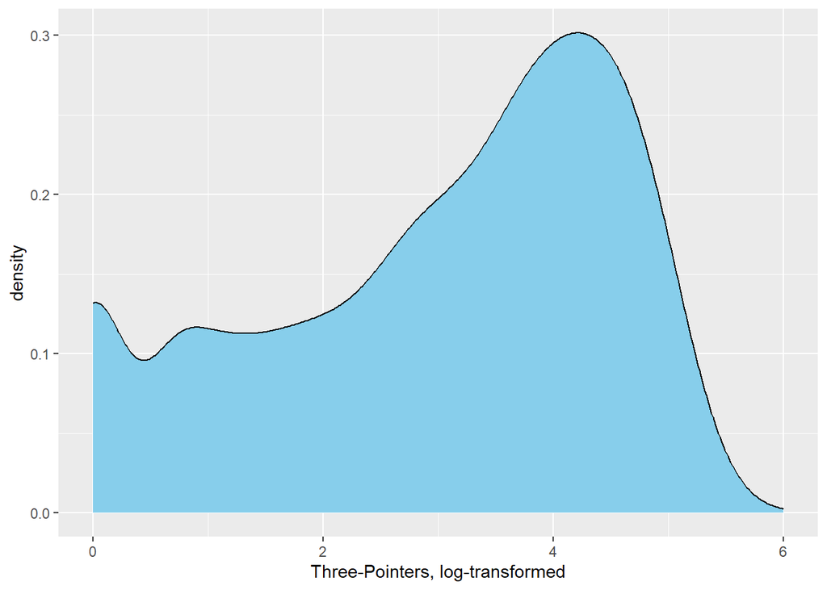

Figure 45: Three-Pointers Distribution (Log-Transformed)

#### Three-Point Percentage

Figure 46 shows the untransformed distribution for three-point percentage, while Figure 47 shows the distribution after the variable’s transformed.

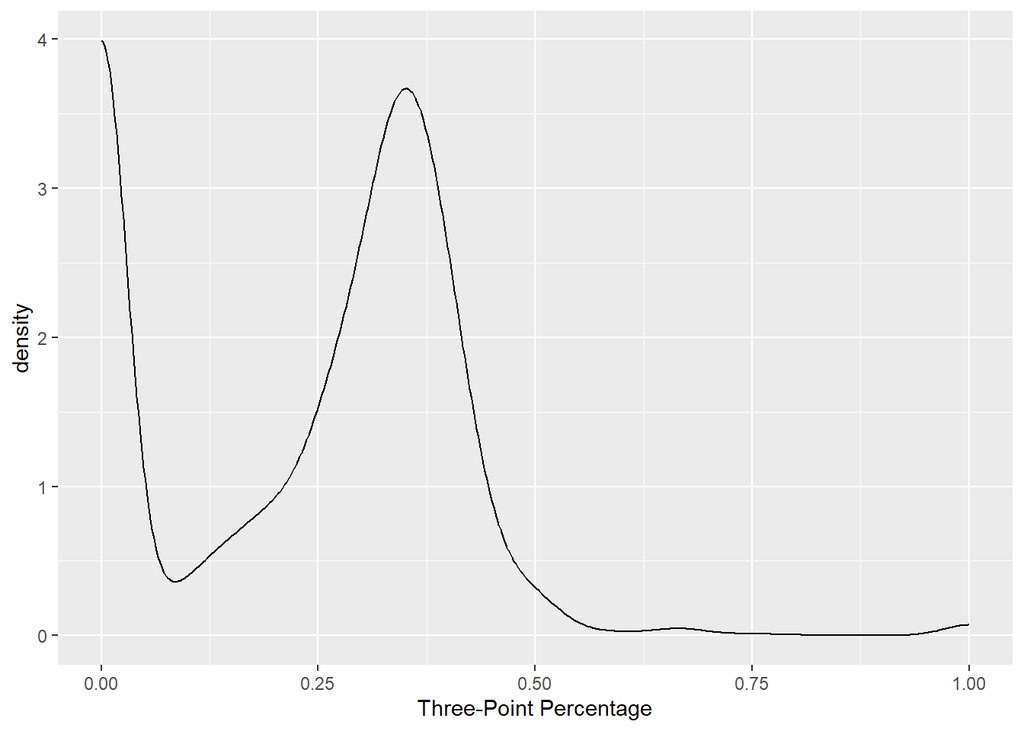

Figure 46: Three-Point Percentage distribution

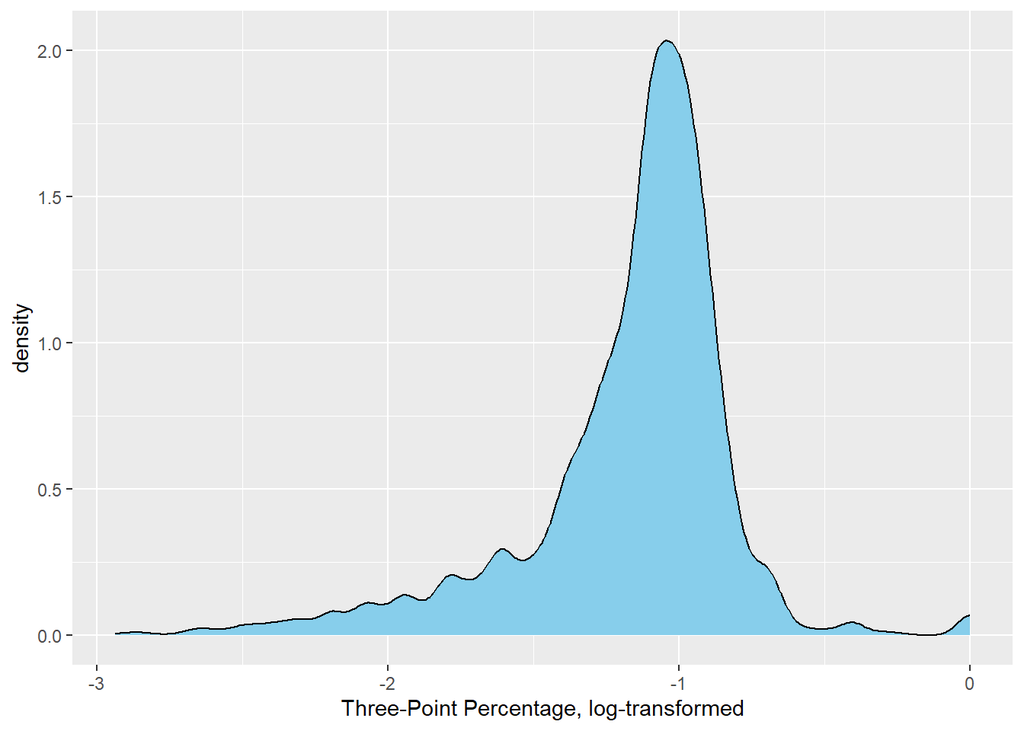

Figure 47: Three-Point Percentage Distribution (Log-Transformed)

#### Blocks

Figure 48 shows the untransformed distribution for blocks, while Figure 49 shows the distribution after the variable’s transformed.

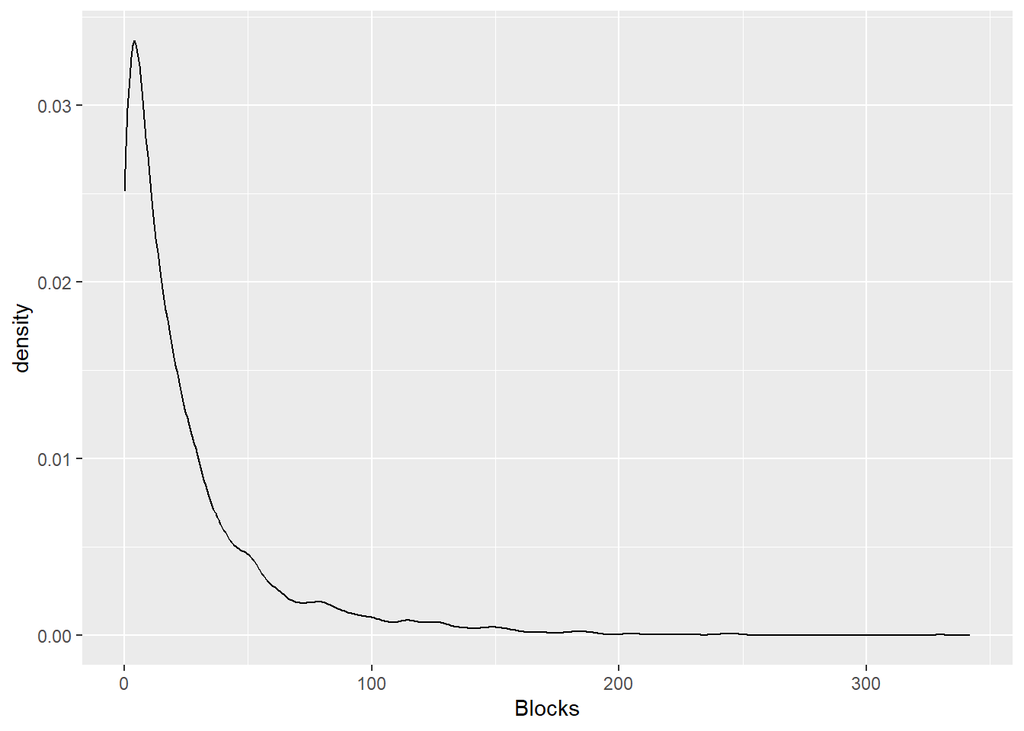

Figure 48: Blocks distribution

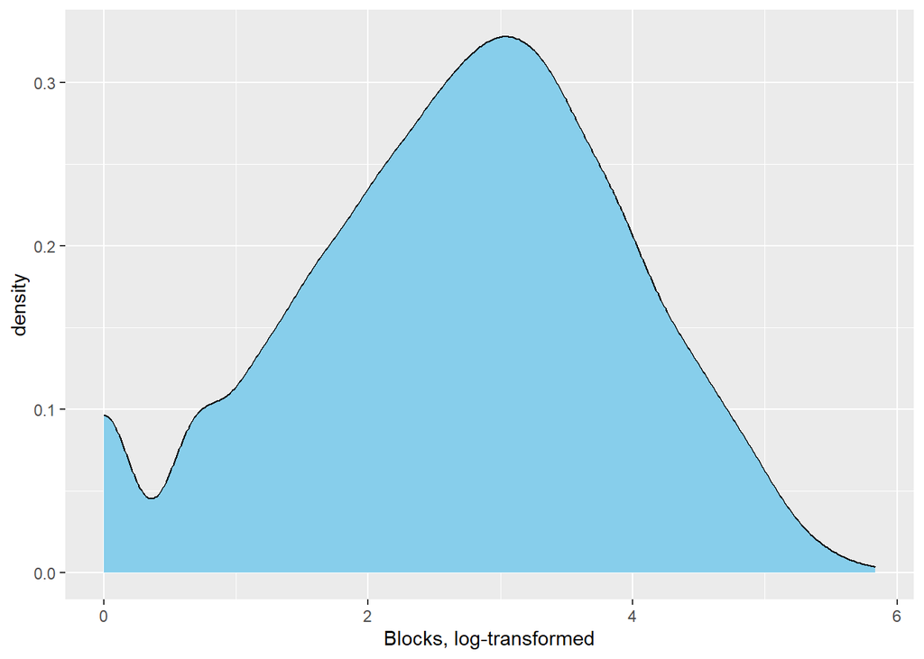

Figure 49: Block Distribution (Log-Transformed)

#### Squaring free throw percentage

Free throw percentage was a special case, since it was actually left-skewed, as displayed in Figure 50.

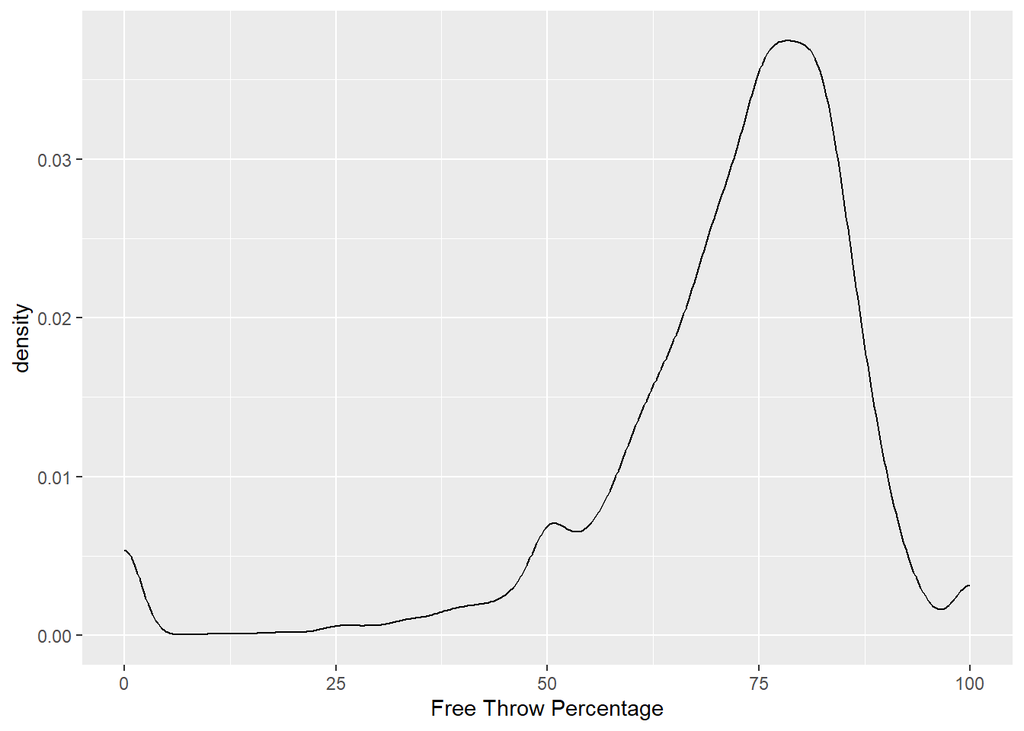

Figure 50: Free Throw Percentage

Thus, to combat this, I squared free throw percentage in the recipe to make the distribution normal by applying a step_mutate to redefine the variable. Here’s what that transformation looked like in Figure 51:

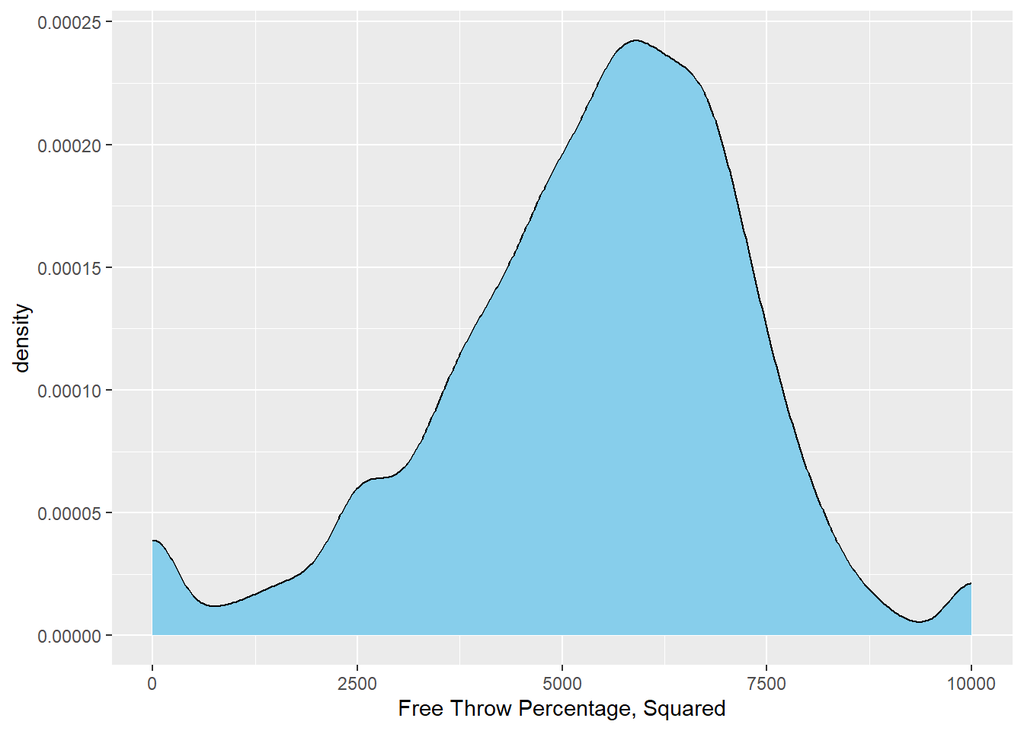

Figure 51: Free Throw Percentage Distribution (Squared)

Those are all of the transformations I made. Now, let’s examine the variable interactions and removals:

### Interactions and Removals

Figure 52 displays the relationships between each of the numeric variables in the cleaned EDA dataset:

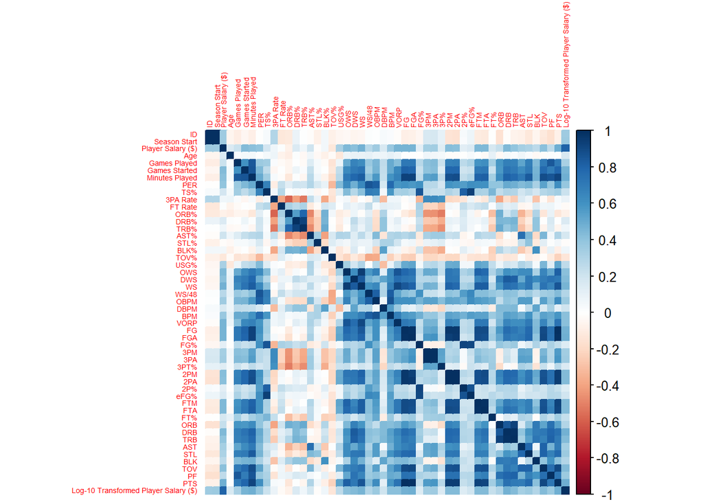

Figure 52: Correlation Plot of Numeric Variables in NBA EDA Salary Dataset

### Removals

I’ve already justified why I got rid of names, un-transformed salary, the ID variable, personal fouls, and teams.

The others I got rid of were steal percentage, three-point rate, free throw rate, offensive rebound percentage, defensive rebound percentage, total rebound percentage, block percentage, and turnover percentage.

### Interactions

As stated in the Resampling and Recipes section, I included 10 variable interactions, and one splines step in my feature-engineered, non-parametric recipe. The correlation plot displays shows that many of these variables correlate with each other, which is why I included them.

For transformations I specified above, I made those transformations in examining the relationship, either plotting their relationship against log-10-transformed salary or referring to the correlation plot in Figure 52:

#### Assist and position

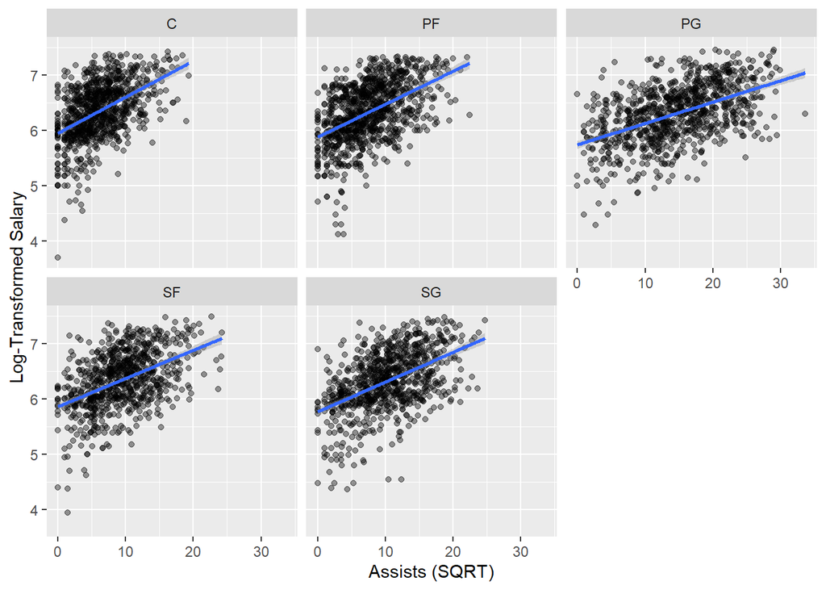

Figure 53: Transformed Assists vs. Log-Transformed Salary, Faceted by Position

Based on Figure 53, it seems like centers and power forwards (even small forwards, to an extent) who rack up many assists tend to see increased salaries at a higher rate than point guards. It isn’t an insanely substantial difference, but it’s one I wanted to explore; since point guards often have the ball the most by virtue of their position, they tend to rack up more assists than players at other positions. Therefore, a taller player who can pass the ball well could be valuable, and this graph hints at such. Thus, I included the interaction.

#### Field Goals and Points

This is pretty self-explanatory – more made shots equals more points. This supports that notion:

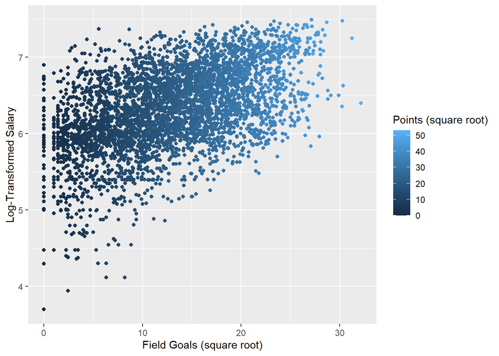

Figure 54: Points and Field Goals (transformed) vs. Log-Transformed Salary

#### Effective Field Goal Percentage (eFG%) and True Shooting Percentage (TS%)

The formulas in calculating these two weighted shooting percentages are pretty similar, only true shooting percentage takes into account free throws. Figure 52 shows that they have a very strong relationship with each other.

#### Offensive Rebounds and Total Rebounds

Also makes sense. More offensive rebounds equals more total rebounds. While this could lead to a linear combination, the step_lincomb() step near the end of my recipes ensures that it isn’t an issue.

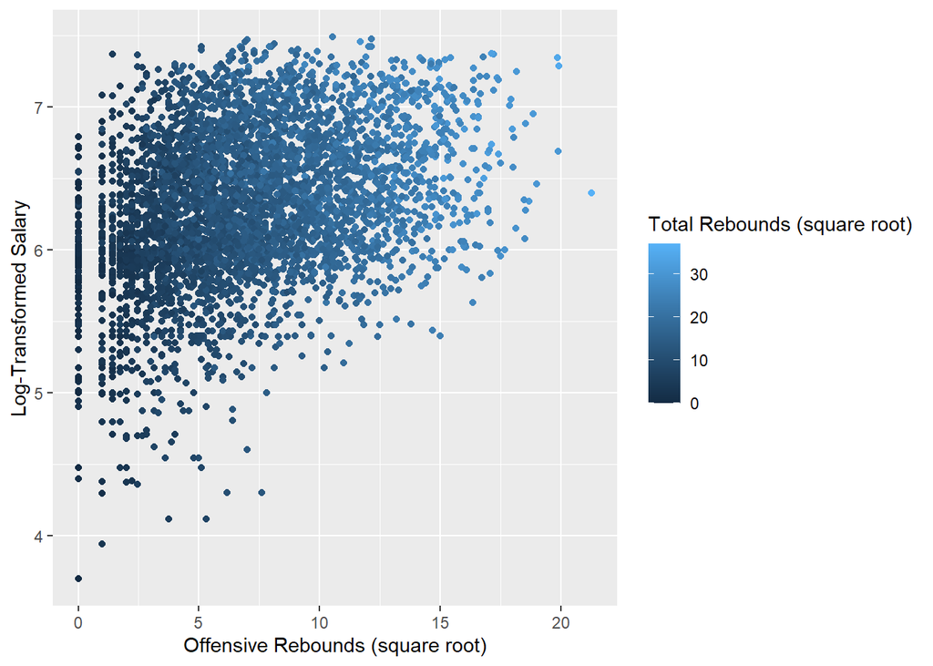

Figure 55: Offensive Rebounds and Total Rebounds (transformed) vs. Log-Transformed Salary

#### Defensive Rebounds and Total Rebounds

Same thing here:

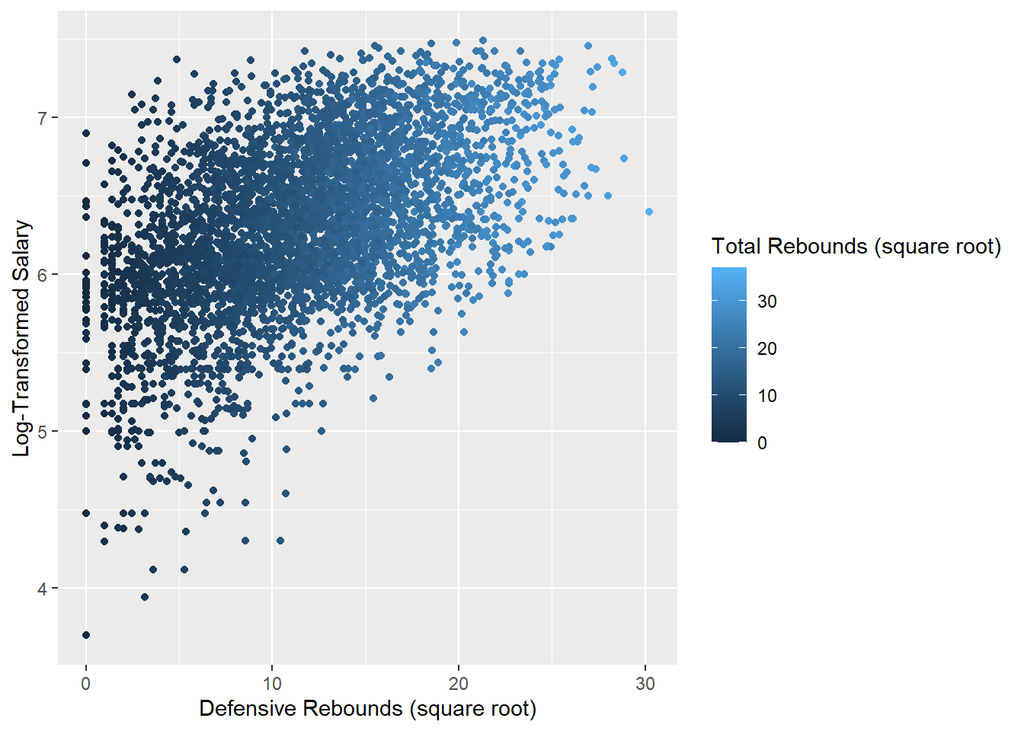

Figure 56: Defensive Rebounds and Total Rebounds (transformed) vs. Log-Transformed Salary

#### Field goals made and attempted

Also generally makes sense, with more attempts, professional basketball playres are more likely to have more total makes. See Figure 52.

#### Games and minutes played

With more games played, it’s very likely someone that someone will have played more minutes. Plus, someone who plays more is more likely to get paid more, as they’re clearly valuable to their team:

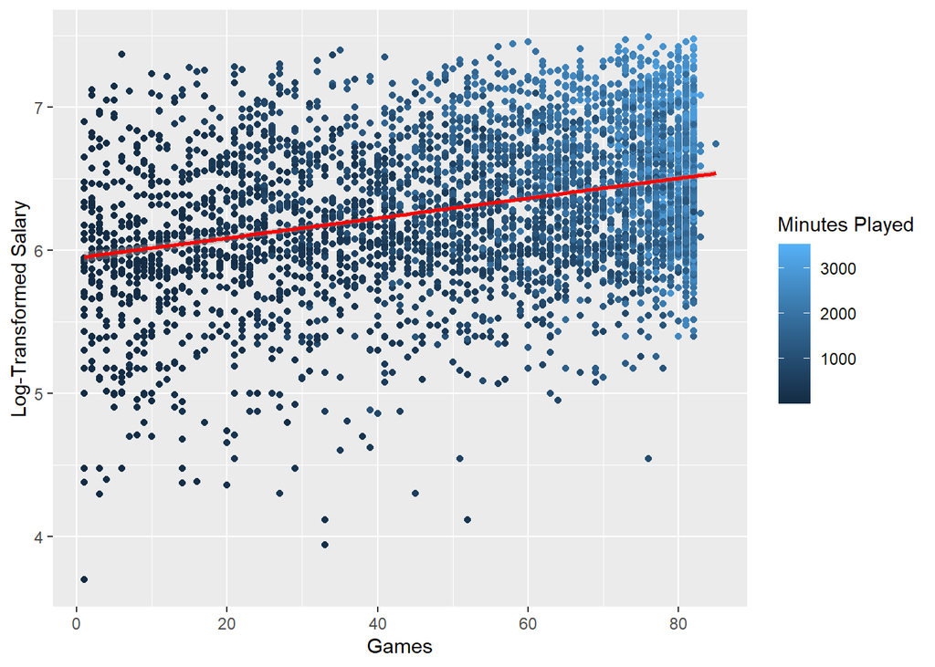

Figure 57: Games and Minutes Played vs. Log-Transformed Salary

#### Offensive Win Shares and Total Win Shares; Defensive Win Shares and Total Win Shares

Total win shares isn’t a direct sum of the two categories, but it’s close – Figure 52 demonstrates that these go hand-in-hand. Plus, the higher one’s win-share total is, it demonstrates their value, which leads to higher salaries.

#### Two-point percentage and eFG%

They have a very strong relationship with each other in Figure 52, which prompted an interaction. This makes sense, as two-point percentage is part of calculating effective field goal percentage.

### Splines

I added one splines step: for age. Here was its univariate distribution:

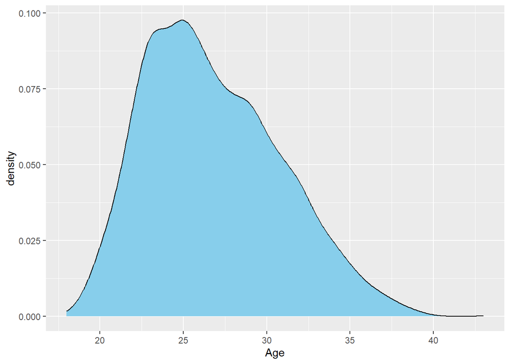

Figure 58: Age Univariate Distribution

This looks relatively normal, but age’s relationship with salary isn’t necessarily a linear one that’s easy to transform, as age is discrete:

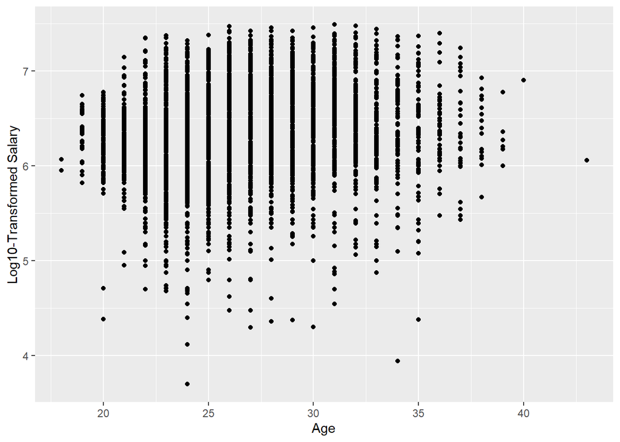

Figure 59: Age vs. Log-Transformed Salary

While Figure 52 indicates that the relationship between age and salary isn’t strong, it’s important – younger players don’t typically make as much, but quality players who get second and third contracts will often get paid much more than rookies as they enter their prime (around 26-32) before they begin retiring and/or physically declining. Because of that, this isn’t necessarily a linear relationship.

Because of that, I implemented a splines transformation here with 3 degrees of freedom. Here’s what that looks like, accounting for the added curves.

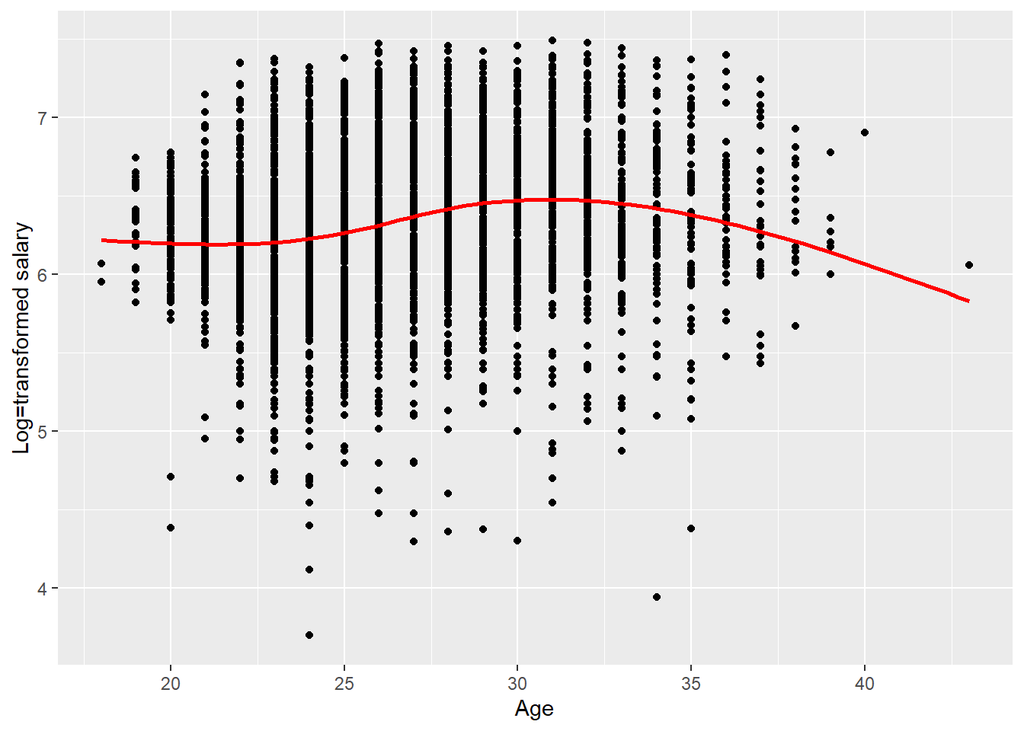

Figure 60: Age vs. Log-Transformed Salary with Splines

Those are all of the recipe transformations that I made after exploring the dataset, which were informed by those plots.

### Table Displaying No Missingness in Cleaned Dataset

This was referred to in the data overview section, specifically, the subsection “Examining Missingness for Target Variable and Cleaned Dataset.” Here is a table demonstrating that that my cleaned dataset did not have missingness (after cleaning and before splitting), which meant I didn’t need to impute values in my recipes:

Table 9: Examining Variable Missingness: 1990-2017

| Variable Name | Number of Observations Missing | Rate of Observations Not Missing |
| --- | --- | --- |
| player_name | 0 | 1 |
| pos | 0 | 1 |
| tm | 0 | 1 |
| number | 0 | 1 |
| season_start | 0 | 1 |
| player_salary | 0 | 1 |
| age | 0 | 1 |
| g | 0 | 1 |
| gs | 0 | 1 |
| mp | 0 | 1 |
| per | 0 | 1 |
| ts_percent | 0 | 1 |
| x3p_ar | 0 | 1 |
| f_tr | 0 | 1 |
| orb_percent | 0 | 1 |
| drb_percent | 0 | 1 |
| trb_percent | 0 | 1 |
| ast_percent | 0 | 1 |
| stl_percent | 0 | 1 |
| blk_percent | 0 | 1 |
| tov_percent | 0 | 1 |
| usg_percent | 0 | 1 |
| ows | 0 | 1 |
| dws | 0 | 1 |
| ws | 0 | 1 |
| ws_48 | 0 | 1 |
| obpm | 0 | 1 |
| dbpm | 0 | 1 |
| bpm | 0 | 1 |
| vorp | 0 | 1 |
| fg | 0 | 1 |
| fga | 0 | 1 |
| fg_percent | 0 | 1 |
| x3p | 0 | 1 |
| x3pa | 0 | 1 |
| x3p_percent | 0 | 1 |
| x2p | 0 | 1 |
| x2pa | 0 | 1 |
| x2p_percent | 0 | 1 |
| e_fg_percent | 0 | 1 |
| ft | 0 | 1 |
| fta | 0 | 1 |
| ft_percent | 0 | 1 |
| orb | 0 | 1 |
| drb | 0 | 1 |
| trb | 0 | 1 |
| ast | 0 | 1 |
| stl | 0 | 1 |
| blk | 0 | 1 |
| tov | 0 | 1 |
| pf | 0 | 1 |
| pts | 0 | 1 |
| log_10_player_salary | 0 | 1 |